# **Capstone project: Data-driven suggestions for HR**

## Description and deliverables

This objective is to analyze the dataset and build predictive models that can provide insights to the Human Resources (HR) department of a large consulting firm.

Deliverables include the model evaluation and interpretation, a data visualization(s), ethical considerations, and the resources used to troubleshoot and find answers or solutions.

### Business scenario and problem:

The HR department at Salifort Motors wants to take some initiatives to improve employee satisfaction levels at the company: what’s likely to make the employee leave the company?

If you can predict employees likely to quit, it might be possible to identify factors that contribute to their leaving. Because it is time-consuming and expensive to find, interview, and hire new employees, increasing employee retention will be beneficial to the company.

### HR dataset dictionary

| Variable | Description |  |
| --- | --- | --- |
| satisfaction_level | Employee-reported job satisfaction level [0–1] |  |
| last_evaluation | Score of employee's last performance review [0–1] |  |
| number_project | Number of projects employee contributes to |  |
| average_monthly_hours | Average number of hours employee worked per month |  |
| time_spend_company | How long the employee has been with the company (years) |  |
| Work_accident | Whether or not the employee experienced an accident while at work |  |
| left | Whether or not the employee left the company |  |
| promotion_last_5years | Whether or not the employee was promoted in the last 5 years |  |
| Department | The employee's department |  |
| salary | The employee's salary (U.S. dollars) |  |

source on [Kaggle](https://www.kaggle.com/datasets/mfaisalqureshi/hr-analytics-and-job-prediction?select=HR_comma_sep.csv).

💭

### Reflect on these questions as you complete the plan stage.

- Who are your stakeholders for this project?
- What are you trying to solve or accomplish?
- What are your initial observations when you explore the data?
- What resources do you find yourself using as you complete this stage? (Make sure to include the links.)
- Do you have any ethical considerations in this stage?

# Import packages

```python
# Import packages
#operations
import pandas as pd
import numpy as np
import os
from scipy import stats
#pre / metric
from sklearn.model_selection import train_test_split, GridSearchCV
from sklearn import metrics
from sklearn.utils import resample
#ml
from sklearn.ensemble import RandomForestClassifier
from sklearn.linear_model import LogisticRegression
from xgboost import XGBClassifier,plot_importance
#visuals
import matplotlib.pyplot as plt
import seaborn as sns
#dump
import pickle as pkl
```

### Load dataset

```python
# Load dataset into a dataframe
df = pd.read_csv("HR_capstone_dataset.csv")
df.head()
```

|  | satisfaction_level | last_evaluation | number_project | average_montly_hours | time_spend_company | Work_accident | left | promotion_last_5years | Department | salary |
| --- | --- | --- | --- | --- | --- | --- | --- | --- | --- | --- |
| 0 | 0.38 | 0.53 | 2 | 157 | 3 | 0 | 1 | 0 | sales | low |
| 1 | 0.80 | 0.86 | 5 | 262 | 6 | 0 | 1 | 0 | sales | medium |
| 2 | 0.11 | 0.88 | 7 | 272 | 4 | 0 | 1 | 0 | sales | medium |
| 3 | 0.72 | 0.87 | 5 | 223 | 5 | 0 | 1 | 0 | sales | low |
| 4 | 0.37 | 0.52 | 2 | 159 | 3 | 0 | 1 | 0 | sales | low |

```python
# basic information about the data
df.info()
```

```
<class 'pandas.core.frame.DataFrame'>
RangeIndex: 14999 entries, 0 to 14998
Data columns (total 10 columns):
 #   Column                 Non-Null Count  Dtype
---  ------                 --------------  -----
 0   satisfaction_level     14999 non-null  float64
 1   last_evaluation        14999 non-null  float64
 2   number_project         14999 non-null  int64
 3   average_montly_hours   14999 non-null  int64
 4   time_spend_company     14999 non-null  int64
 5   Work_accident          14999 non-null  int64
 6   left                   14999 non-null  int64
 7   promotion_last_5years  14999 non-null  int64
 8   Department             14999 non-null  object
 9   salary                 14999 non-null  object
dtypes: float64(2), int64(6), object(2)
memory usage: 1.1+ MB
```

## EDA and data cleaning

### Descriptive statistics

```python
# Gather descriptive statistics about the data
df.describe(include="all")
```

|  | satisfaction_level | last_evaluation | number_project | average_montly_hours | time_spend_company | Work_accident | left | promotion_last_5years | Department | salary |
| --- | --- | --- | --- | --- | --- | --- | --- | --- | --- | --- |
| count | 14999.000000 | 14999.000000 | 14999.000000 | 14999.000000 | 14999.000000 | 14999.000000 | 14999.000000 | 14999.000000 | 14999 | 14999 |
| unique | NaN | NaN | NaN | NaN | NaN | NaN | NaN | NaN | 10 | 3 |
| top | NaN | NaN | NaN | NaN | NaN | NaN | NaN | NaN | sales | low |
| freq | NaN | NaN | NaN | NaN | NaN | NaN | NaN | NaN | 4140 | 7316 |
| mean | 0.612834 | 0.716102 | 3.803054 | 201.050337 | 3.498233 | 0.144610 | 0.238083 | 0.021268 | NaN | NaN |
| std | 0.248631 | 0.171169 | 1.232592 | 49.943099 | 1.460136 | 0.351719 | 0.425924 | 0.144281 | NaN | NaN |
| min | 0.090000 | 0.360000 | 2.000000 | 96.000000 | 2.000000 | 0.000000 | 0.000000 | 0.000000 | NaN | NaN |
| 25% | 0.440000 | 0.560000 | 3.000000 | 156.000000 | 3.000000 | 0.000000 | 0.000000 | 0.000000 | NaN | NaN |
| 50% | 0.640000 | 0.720000 | 4.000000 | 200.000000 | 3.000000 | 0.000000 | 0.000000 | 0.000000 | NaN | NaN |
| 75% | 0.820000 | 0.870000 | 5.000000 | 245.000000 | 4.000000 | 0.000000 | 0.000000 | 0.000000 | NaN | NaN |
| max | 1.000000 | 1.000000 | 7.000000 | 310.000000 | 10.000000 | 1.000000 | 1.000000 | 1.000000 | NaN | NaN |

### Rename columns: `snake_case`, spelling, conciseness

```python
df.columns = [x.lower().replace(" ","_") for x in df]
df.rename(columns={'average_montly_hours':'average_hrs_month', 'time_spend_company':"tenure_years","promotion_last_5years":"promo_in_5yrs"},inplace=True)
df.columns
```

```
Index(['satisfaction_level', 'last_evaluation', 'number_project',
       'average_hrs_month', 'tenure_years', 'work_accident', 'left',
       'promo_in_5yrs', 'department', 'salary'],
      dtype='object')
```

### Check missing values

```python
# Check for missing values
df.isna().sum()
```

```
satisfaction_level    0
last_evaluation       0
number_project        0
average_hrs_month     0
tenure_years          0
work_accident         0
left                  0
promo_in_5yrs         0
department            0
salary                0
dtype: int64
```

### Check duplicates

```python
# Inspect some rows containing duplicates as needed
df[df.duplicated(keep=False)]
```

|  | satisfaction_level | last_evaluation | number_project | average_hrs_month | tenure_years | work_accident | left | promo_in_5yrs | department | salary |
| --- | --- | --- | --- | --- | --- | --- | --- | --- | --- | --- |
| 0 | 0.38 | 0.53 | 2 | 157 | 3 | 0 | 1 | 0 | sales | low |
| 1 | 0.80 | 0.86 | 5 | 262 | 6 | 0 | 1 | 0 | sales | medium |
| 2 | 0.11 | 0.88 | 7 | 272 | 4 | 0 | 1 | 0 | sales | medium |
| 3 | 0.72 | 0.87 | 5 | 223 | 5 | 0 | 1 | 0 | sales | low |
| 4 | 0.37 | 0.52 | 2 | 159 | 3 | 0 | 1 | 0 | sales | low |
| ... | ... | ... | ... | ... | ... | ... | ... | ... | ... | ... |
| 14994 | 0.40 | 0.57 | 2 | 151 | 3 | 0 | 1 | 0 | support | low |
| 14995 | 0.37 | 0.48 | 2 | 160 | 3 | 0 | 1 | 0 | support | low |
| 14996 | 0.37 | 0.53 | 2 | 143 | 3 | 0 | 1 | 0 | support | low |
| 14997 | 0.11 | 0.96 | 6 | 280 | 4 | 0 | 1 | 0 | support | low |
| 14998 | 0.37 | 0.52 | 2 | 158 | 3 | 0 | 1 | 0 | support | low |

5346 rows × 10 columns

```python
# Drop duplicates and save resulting dataframe in a new variable as needed
df_cleaned = df.drop_duplicates()
del df
# Display first few rows of new dataframe as needed
df_cleaned.head()
```

|  | satisfaction_level | last_evaluation | number_project | average_hrs_month | tenure_years | work_accident | left | promo_in_5yrs | department | salary |
| --- | --- | --- | --- | --- | --- | --- | --- | --- | --- | --- |
| 0 | 0.38 | 0.53 | 2 | 157 | 3 | 0 | 1 | 0 | sales | low |
| 1 | 0.80 | 0.86 | 5 | 262 | 6 | 0 | 1 | 0 | sales | medium |
| 2 | 0.11 | 0.88 | 7 | 272 | 4 | 0 | 1 | 0 | sales | medium |
| 3 | 0.72 | 0.87 | 5 | 223 | 5 | 0 | 1 | 0 | sales | low |
| 4 | 0.37 | 0.52 | 2 | 159 | 3 | 0 | 1 | 0 | sales | low |

### Check outliers

Visualize distribution of `tenure` to detect outliers

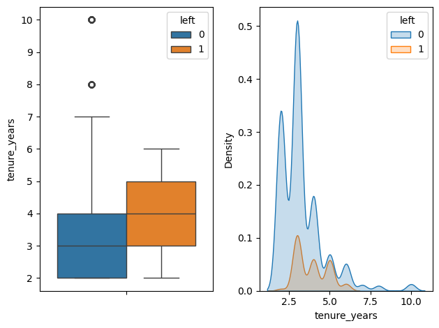

```python
plt.subplot(121)
sns.boxplot(df_cleaned,y="tenure_years",hue="left")
plt.subplot(122)
sns.kdeplot(df_cleaned,x="tenure_years",hue="left",multiple="layer",fill=True,bw_adjust=1.3)
plt.tight_layout()
plt.show()
```

```python
df_cleaned = pd.get_dummies(df_cleaned,drop_first=False,columns=["salary","department"])
```

Change Department to Ordinal?

```python
# convert departments into ordinal var
def dept_to_ordinal(df_cleaned):
    depts=df_cleaned["department"].unique()
    print(depts)
    dept_ord={}
    for ix,i in enumerate(depts):
        dept_ord[i]=ix
    print(dept_ord)
    df_cleaned["dept_ordinal"]=df_cleaned["department"].apply(lambda x:dept_ord[x])
    return df_cleaned
```

```python
df_=df_cleaned.copy()
df_.head()
```

|  | satisfaction_level | last_evaluation | number_project | average_hrs_month | tenure_years | work_accident | left | promo_in_5yrs | salary_high | salary_low | ... | department_IT | department_RandD | department_accounting | department_hr | department_management | department_marketing | department_product_mng | department_sales | department_support | department_technical |
| --- | --- | --- | --- | --- | --- | --- | --- | --- | --- | --- | --- | --- | --- | --- | --- | --- | --- | --- | --- | --- | --- |
| 0 | 0.38 | 0.53 | 2 | 157 | 3 | 0 | 1 | 0 | False | True | ... | False | False | False | False | False | False | False | True | False | False |
| 1 | 0.80 | 0.86 | 5 | 262 | 6 | 0 | 1 | 0 | False | False | ... | False | False | False | False | False | False | False | True | False | False |
| 2 | 0.11 | 0.88 | 7 | 272 | 4 | 0 | 1 | 0 | False | False | ... | False | False | False | False | False | False | False | True | False | False |
| 3 | 0.72 | 0.87 | 5 | 223 | 5 | 0 | 1 | 0 | False | True | ... | False | False | False | False | False | False | False | True | False | False |
| 4 | 0.37 | 0.52 | 2 | 159 | 3 | 0 | 1 | 0 | False | True | ... | False | False | False | False | False | False | False | True | False | False |

5 rows × 21 columns

### Outliers

```python
# Determine the number of rows containing outliers
iqr_all={}
for col in df_.columns:

    data = df_[col]
    if data.value_counts().count() > 2 and data.dtype!="O":
        iqr = data.quantile(.75) - data.quantile(.25)
        upper_lim = data.quantile(.75) + iqr * 1.5
        lower_lim = data.quantile(.25) - iqr * 1.5
        outliers = ((data<=lower_lim)|(data>=upper_lim)).sum()
        # export outlier data?
        #outliers_df = data[data > lower_lim & data < upper_lim]
        print(col, outliers)
```

```
satisfaction_level 0
last_evaluation 0
number_project 0
average_hrs_month 0
tenure_years 824
```

💭

### Reflect on these questions as you complete the analyze stage.

- What did you observe about the relationships between variables?
- What do you observe about the distributions in the data?
- What transformations did you make with your data? Why did you chose to make those decisions?
- What are some purposes of EDA before constructing a predictive model?
- What resources do you find yourself using as you complete this stage? (Make sure to include the links.)
- Do you have any ethical considerations in this stage?

## EDA: Class Differences

```python
# Get numbers of people who left vs. stayed
print("By Percent\n",df_.value_counts("left",normalize=True))
```

```
By Percent
 left
0    0.833959
1    0.166041
Name: proportion, dtype: float64
```

```python
df_stay = df_[df_["left"]==0]
df_left = df_[df_["left"]==1]
```

EDA: Left class descriptive statistics

```python
df_left.describe()
```

|  | satisfaction_level | last_evaluation | number_project | average_hrs_month | tenure_years | work_accident | left | promo_in_5yrs |
| --- | --- | --- | --- | --- | --- | --- | --- | --- |
| count | 1991.000000 | 1991.000000 | 1991.000000 | 1991.000000 | 1991.000000 | 1991.000000 | 1991.0 | 1991.000000 |
| mean | 0.440271 | 0.721783 | 3.883476 | 208.162230 | 3.881467 | 0.052737 | 1.0 | 0.004018 |
| std | 0.265207 | 0.197436 | 1.817139 | 61.295145 | 0.974041 | 0.223565 | 0.0 | 0.063277 |
| min | 0.090000 | 0.450000 | 2.000000 | 126.000000 | 2.000000 | 0.000000 | 1.0 | 0.000000 |
| 25% | 0.110000 | 0.520000 | 2.000000 | 146.000000 | 3.000000 | 0.000000 | 1.0 | 0.000000 |
| 50% | 0.410000 | 0.790000 | 4.000000 | 226.000000 | 4.000000 | 0.000000 | 1.0 | 0.000000 |
| 75% | 0.730000 | 0.910000 | 6.000000 | 262.500000 | 5.000000 | 0.000000 | 1.0 | 0.000000 |
| max | 0.920000 | 1.000000 | 7.000000 | 310.000000 | 6.000000 | 1.000000 | 1.0 | 1.000000 |

### Data visualizations

#### Helper Function: Hypothesis Testing

```python
def hypocheck(col_list,aliases):
    col_alias= {col:alias for (col,alias) in zip(col_list,aliases)}
    for col in col_list:
        pval=stats.ttest_ind(
            a=df_left[col],
            b=df_stay[col],
            equal_var=False
            )[1]
        print(f"It is {str(pval<0.05).lower()} (at p-value {pval:.3}) that employees' likelihood towards {col_alias[col]}s differs based on their choice to leave or stay.")
```

#### Pair Plot: Left

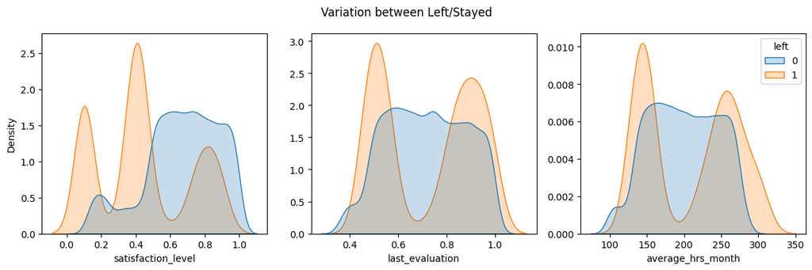

```python
fg, axes = plt.subplots(1,3)
fg.suptitle("Variation between Left/Stayed")
fg.set_size_inches(12,4)
for ind,col in enumerate(df_[["satisfaction_level","last_evaluation","average_hrs_month"]]):
    sns.kdeplot(df_,x=col,hue="left",ax=axes[ind],common_norm=False,fill=True,bw_adjust=1)
    if ind<2:
        axes[ind].get_legend().remove()
    if ind>0:
        axes[ind].set(ylabel=None)
fg.tight_layout()
plt.show()
```

```python
var = ["satisfaction_level"]
hypocheck(var,var)
```

```
It is true (at p-value 1.19e-228) that employees' likelihood towards satisfaction_levels differs based on their choice to leave or stay.
```

```python
np.random.seed(6)
minnesota_ages1 = stats.poisson.rvs(loc=18, mu=33, size=30)
minnesota_ages2 = stats.poisson.rvs(loc=18, mu=13, size=20)
minnesota_ages = np.concatenate((minnesota_ages1, minnesota_ages2))
#np.random.seed(12)
wisconsin_ages1 = stats.poisson.rvs(loc=18, mu=33, size=30)
wisconsin_ages2 = stats.poisson.rvs(loc=18, mu=13, size=20)
wisconsin_ages = np.concatenate((wisconsin_ages1, wisconsin_ages2))
print( minnesota_ages.mean() )
print( wisconsin_ages.mean() )
stats.ttest_ind(a= minnesota_ages,
                b= wisconsin_ages,
                equal_var=False)  # Assume samples have equal variance?
```

```
43.34
42.28
```

```
TtestResult(statistic=np.float64(0.5058210501754471), pvalue=np.float64(0.6141475280631097), df=np.float64(95.52700904007803))
```

#### Discrete Column Differences: Number of projects, Tenure

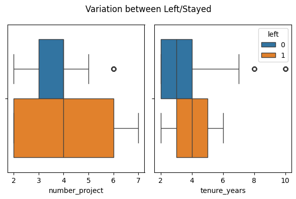

```python
fg, axes = plt.subplots(1,2)
fg.suptitle("Variation between Left/Stayed")
fg.set_size_inches(6,4)
dis_cols = ["number_project","tenure_years"]
for ind,col in enumerate(df_[dis_cols]):
    sns.boxplot(df_,x=col,hue="left",ax=axes[ind])
    if ind<1:
        axes[ind].get_legend().remove()
    if ind>0:
        axes[ind].set(ylabel=None)
fg.tight_layout()
plt.show()
```

```python
hypocheck(dis_cols,dis_cols)
```

```
It is true (at p-value 0.0211) that employees' likelihood towards number_projects differs based on their choice to leave or stay.
It is true (at p-value 5.79e-119) that employees' likelihood towards tenure_yearss differs based on their choice to leave or stay.
```